# takada_1126HW_331crossvalscore

## 3.3 Model evaluation: quantifying the quality of predictions

3.3.1 The "scoring" parameter: defining model evaluation rules モデルevaluationの際に使用するスコアリングのパラメータ

3.3.2 Classification metrics 損失関数などで使用する分類のためのパラメータ

3.3.3 Multilabel ranking metrics outcomeの分類が3種類以上あるときのパラメータ

3.3.4 Regression metrics 回帰のため

3.3.5 Clustering metrics クラスタリングのため

3.3.6 Dummy estimators 偏ったデータセットを作成する

# "Model selection and evaluation using tools, such as model_selection.GridSearchCV and model_selection.cross_val_score, take a scoring parameter that controls what metric they apply to the estimators evaluated."

This sentence says you can use model_selection.GridSearchCV and model_selection.cross_val_score for model selection.

The site you visit provides "Examples". You can change "cv" parameter of cross_val_score() function.

```python
# sklearn.model_selection.cross_val_score
from sklearn import datasets, linear_model
from sklearn.model_selection import cross_val_score
import pandas as pd#中身みるために入れておく
diabetes = datasets.load_diabetes()
type(diabetes)
```

```
sklearn.utils.Bunch
```

```python
pd.DataFrame(diabetes.data, columns=diabetes.feature_names).head()
```

|  | age | sex | bmi | bp | s1 | s2 | s3 | s4 | s5 | s6 |
| --- | --- | --- | --- | --- | --- | --- | --- | --- | --- | --- |
| 0 | 0.038076 | 0.050680 | 0.061696 | 0.021872 | -0.044223 | -0.034821 | -0.043401 | -0.002592 | 0.019908 | -0.017646 |
| 1 | -0.001882 | -0.044642 | -0.051474 | -0.026328 | -0.008449 | -0.019163 | 0.074412 | -0.039493 | -0.068330 | -0.092204 |
| 2 | 0.085299 | 0.050680 | 0.044451 | -0.005671 | -0.045599 | -0.034194 | -0.032356 | -0.002592 | 0.002864 | -0.025930 |
| 3 | -0.089063 | -0.044642 | -0.011595 | -0.036656 | 0.012191 | 0.024991 | -0.036038 | 0.034309 | 0.022692 | -0.009362 |
| 4 | 0.005383 | -0.044642 | -0.036385 | 0.021872 | 0.003935 | 0.015596 | 0.008142 | -0.002592 | -0.031991 | -0.046641 |

糖尿病患者 442 人の検査数値と 1 年後の疾患進行状況（正規化済み）。

```python
help(diabetes)
```

[output not shown]

[output cut: 45 more lines]

[output not shown]

```python
dir(diabetes)#objectの中身の関数の確認
```

```
['DESCR', 'data', 'feature_names', 'target']
```

```python
diabetes.data
```

```
array([[ 0.03807591,  0.05068012,  0.06169621, ..., -0.00259226,
         0.01990842, -0.01764613],
       [-0.00188202, -0.04464164, -0.05147406, ..., -0.03949338,
        -0.06832974, -0.09220405],
       [ 0.08529891,  0.05068012,  0.04445121, ..., -0.00259226,
         0.00286377, -0.02593034],
       ...,
       [ 0.04170844,  0.05068012, -0.01590626, ..., -0.01107952,
        -0.04687948,  0.01549073],
       [-0.04547248, -0.04464164,  0.03906215, ...,  0.02655962,
         0.04452837, -0.02593034],
       [-0.04547248, -0.04464164, -0.0730303 , ..., -0.03949338,
        -0.00421986,  0.00306441]])
```

```python
diabetes.feature_names
```

```
['age', 'sex', 'bmi', 'bp', 's1', 's2', 's3', 's4', 's5', 's6']
```

# cross validataion

```python
X = diabetes.data[:150]
y = diabetes.target[:150]
lasso = linear_model.Lasso()
```

```python
cross_val_score(lasso, X, y, cv=2)
```

```
array([0.27893788, 0.18442104])
```

```python
sum(cross_val_score(lasso, X, y, cv=2))/len(cross_val_score(lasso, X, y, cv=2))
```

```
0.23167946173178772
```

```python
cross_val_score(lasso, X, y, cv=3)#default
```

```
array([0.33150734, 0.08022311, 0.03531764])
```

```python
sum(cross_val_score(lasso, X, y, cv=3))/len(cross_val_score(lasso, X, y, cv=3))
```

```
0.14901602799979088
```

```python
cross_val_score(lasso, X, y, cv=4)
```

```
array([ 0.3392459 ,  0.12286347,  0.16482017, -0.04610521])
```

```python
sum(cross_val_score(lasso, X, y, cv=4))/len(cross_val_score(lasso, X, y, cv=4))
```

```
0.14520608279308234
```

```python
cross_val_score(lasso, X, y, cv=5)
```

```
array([0.29828759, 0.22414975, 0.15479913, 0.25519691, 0.17109036])
```

```python
sum(cross_val_score(lasso, X, y, cv=5))/len(cross_val_score(lasso, X, y, cv=5))
```

```
0.22070474842317603
```

```python
cross_val_score(lasso, X, y, cv=10)
```

```
array([ 0.34557351,  0.34848715,  0.26654262, -0.01126674,  0.24875619,
        0.08731544,  0.13386583,  0.14000888,  0.2873109 ,  0.00960079])
```

```python
sum(cross_val_score(lasso, X, y, cv=10))/len(cross_val_score(lasso, X, y, cv=10))
```

```
0.1856194569313399
```

```python
def meanlambda(n,cv):
    X = diabetes.data[:n]
    y = diabetes.target[:n]
    return sum(cross_val_score(lasso, X, y, cv=cv))/len(cross_val_score(lasso, X, y, cv=cv))
```

```python
(meanlambda(150,2)) == (sum(cross_val_score(lasso, X, y, cv=2))/len(cross_val_score(lasso, X, y, cv=2)))
```

```
True
```

```python
res=[]
for i in range(2,10):
    res.append(meanlambda(150,i))
```

```python
res
```

```
[0.23167946173178772,
 0.14901602799979088,
 0.14520608279308234,
 0.22070474842317603,
 0.19626606434881522,
 0.1881758293819826,
 0.18236824256692907,
 0.17248120826201413]
```

```python
import matplotlib.pyplot as plt
import numpy as np
%matplotlib inline
```

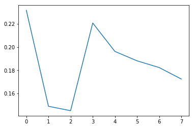

```python
plt.plot(res)
```

```python
list(range(2,10))
```

```
[2, 3, 4, 5, 6, 7, 8, 9]
```

```python
def cvplot(N,kai):
    res=[]
    for i in range(2,2+kai):
        res.append(meanlambda(N,i))
    return plt.plot(res)
```

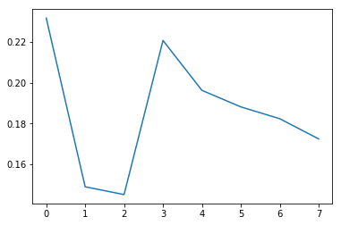

```python
cvplot(150,8)
```

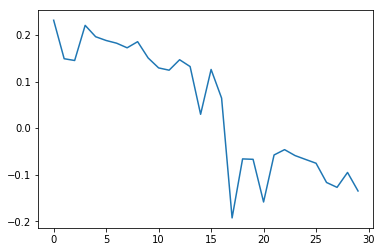

```python
cvplot(150,30)
```

```python
meanlambda(150,30)
```

```
-0.09529554439139797
```

[lassoのパラメータは何？](https://scikit-learn.org/stable/modules/generated/sklearn.linear_model.Lasso.html)

```python
help(lasso)
```

[output not shown]

[output cut: 227 more lines]

[output not shown]